# HG4052 · Week 3 · Seeing Speech

HG4052 · Speech Synthesis & Recognition

Jump to a slide · M or O toggles · Esc closes

ɑ

HG4052 · Speech Synthesis & Recognition / Week 3

# Seeing Speech.

Time and Frequency.

Chenzi Xu · chenzi.xu@ntu.edu.sg

→ / space to advance · F for fullscreen · M for the slide menu

f

Today

## Roadmap

- Week 1’s digitising choices reviewed, then **where they live on disk**: the WAV file, PCM and μ-law
- What sampling cannot hear: **Nyquist & aliasing**
- The hardest idea: **Fourier**, every sound as a sum of sines, taken one **window** at a time
- **Filters and resonators**: how a spectrum is reshaped
- The **spectrogram**: speech made visible
- **Source–filter**: the theory of speech production, made quantitative

t

The shape of the morning

## Today, by the clock

**09:40** Lecture I: sound in the air, then trapped in numbers

**10:40** Break (10 min)

**10:50** Lecture II: Fourier, spectrograms, source–filter, with sound ON

**11:40** Break + Praat and Colab setup (10 min)

**11:50** Practical: record it, break it, rebuild it

**12:50** Wrap-up

Before new math · 3 minutes, tell your neighbour

## Four echoes from Week 2

1. Bayes' rule, in one line?

posterior ∝ likelihood × prior: how well the word explains the sound, times how expected the word was

2. Why do decoders add scores instead of multiplying?

log probabilities: products become sums, and nothing underflows to zero

3. A probability of ¼ is how many bits of surprisal?

surprisal = −log₂ P, so −log₂(¼) = log₂ 4 = **2 bits**: ¼ is two halvings of certainty, one bit each

4. The held-out rule?

models are evaluated on data they never saw

Today the sound itself finally becomes the list of numbers Week 1 promised.

From articulation to air

## You know how speech is made; today, how it travels

### Frequency → pitch

Cycles per second (Hz). F0 is the **physical** repetition rate of the folds (~100–250 Hz); pitch is what your ear **makes of it**: the melody.

### Amplitude → loudness

Pressure swing (physical), heard logarithmically as loudness. Decibels measure amplitude ratios: dB = 20 log₁₀(A/A<sub>ref</sub>), so ×2 = +6 dB and ×10 = +20 dB.

### Shape → quality

Two sounds with the same pitch and loudness can still differ: the **waveform's shape** carries vowel quality and consonant identity.

**LIVE:** a pure 120 Hz tone vs an [ɑː] at the same 120 Hz: same frequency, utterly different sound. Whatever “quality” is, it lives in the shape. By the end of today you'll know its real name: **the spectrum**.

or speak an [ɑ] yourself and match the tone’s pitch by ear

What actually travels

## A pressure wave is a pattern, not a thing

the wave enters still air from the left; dark bands = compressed, sparse = rarefied; waveform = one point’s history

Air molecules bunch up (compression) and thin out (rarefaction); each molecule only jiggles in place while the **pattern** races outward at ~343 m/s. The middle curve is pressure **across space** at one instant; the bottom one is pressure at one point **across time** (the **waveform**).

wavelength = speed / frequency λ = c / f, equivalently c = f × λ 100 Hz → 3.4 m · 4 kHz → 8.6 cm

Math interlude · one unit before the wheel

## Radians: 2π is one full turn

The radius wrapped along the rim fits 2π ≈ 6.28 times: that is all a radian is.

The definition

angle in radians = arc length / radius

No degrees anywhere: the circle measures itself with its own radius.

The only conversions you need

| turn | radians | degrees |
| --- | --- | --- |
| quarter | π/2 | 90° |
| half | π | 180° |
| **full** | **2π ≈ 6.283** | **360°** |

Why it matters next slide

A tone at f Hz makes **f full turns per second**, and each turn is 2π radians: so the angle grows as 2πft. That is the 2π inside sin(2πft): bookkeeping, not magic.

Math interlude · ten minutes, no calculus

## One spinning wheel explains every pure tone

click again to pause

y(t) = A · sin(2πft + φ)

**A, the wheel's radius** → how far the wave swings: loudness.  
**f, laps per second** → how fast it repeats: pitch, in Hz.  
**2πf, radians per second** → f laps × 2π radians per lap (last slide); ×t gives the angle now. Its name: **angular frequency**, ω.  
**φ, the starting angle** → where in the lap you began. Ears mostly ignore it (we test this by ear later today); machines keep track.

DEFINITION

Sinusoid

y(t) = A sin(2πft + φ): the waveform of perfectly steady oscillation, fixed by three numbers: amplitude, frequency, phase. The building block of all sounds.

Jurafsky & Martin, *SLP* 3rd ed., §15.4.1, eq. (15.3).

Quick check · 3 minutes, pencils out

## Try it: read the knobs

EX 3.1

A tone is described by y(t) = 0.4 · sin(2π · 250 · t). Read off: the amplitude, the frequency, and the period.

EX 3.2

A wheel spins 100 times per second with radius 2, and starts a quarter-turn ahead of the usual starting point. Write y(t). Does the tone sound any different for it?

Worked answers in the appendix at the end of this deck.

Two kinds of sound

## Speech alternates between buzz and hiss

[ɑ] · periodic: the pattern repeats (voicing)

[s] · aperiodic: turbulent noise, no repeat

A repeating pattern has a **period**; 1/period is the **fundamental frequency, F0**: how many times the pattern repeats per second. Pitch is what your ear makes of F0.

Noise has no period, so no F0: just energy smeared across frequencies. The ear still hears **where that energy sits**: /s/ is brighter than /ʃ/.

Every segment you transcribe is some mix of these two ingredients.

Digitizing · Week 1 in sixty seconds

## Sampling = filming the wave

continuous pressure wave → snapshots (dots) → quantized steps (the ruler's precision)

**Sample rate**: how often we look. 16,000 **samples** per second for speech research; 44,100 for CDs.

**Bit depth**: how precisely we measure each snapshot. 16 bits ≈ 65,536 ruler marks.

That's the whole trick. A WAV file is these dots, nothing more: **Week 1's “list of numbers”, born**.

The second ruler · amplitude, not time

## Quantisation: rounding every sample to a rung

- Sampling fixes **when** we look; quantisation fixes **how finely** we measure each look
- **b** bits give **2^b rungs**; each extra bit halves the step and adds about **6 dB** of dynamic range (6 dB is decibels for a factor of 2: 20 log₁₀ 2 ≈ 6)
- The rounding error behaves like a faint **noise floor**, not a volume change: grainier, never softer
- 16 bits give 65,536 rungs, about **96 dB**: the rounding noise sits far below the hiss a real microphone and room add anyway, so the steps stay masked and inaudible

The other ruler · listen

## How few bits can you get away with?

Same sentence, coarser and coarser rulers: 16 bits, then 8, then 4, then 3. Predict first: at which step do you start to hear it?

Playback from pre-rendered clips (bitdepth_16/8/4/3.wav); the practical notebook has the code that made them.

What coarse quantization sounds like

Not softer, but **grainier**: the rounding errors behave like added noise. Bit depth buys dynamic range (~6 dB per bit); 16 bits is plenty for speech.

s

The catch · reviewed, now with phonetic consequences

## Two samples per cycle, or the frequency is lost

you can only capture frequencies **below sample rate ÷ 2** (the Nyquist limit)

### 16 kHz recording → nothing above 8 kHz

Fine for vowels (formants live below ~3.5 kHz). Risky for sibilants: /s/ keeps much of its energy at 4–8 kHz and beyond.

### Telephone: 8 kHz → nothing above 4 kHz

That's why “sailing” vs “failing” is a phone-call classic: the /s/–/f/ cue lives exactly in the band the channel throws away.

You will **hear** this happen in the practical: resample your own /s/ to a 4 kHz sample rate, and everything above 2 kHz is discarded: the sharp hiss goes dull. A phonetic fact, manufactured by an engineering decision.

What people actually pick, and why

## The standard rate × depth settings

Telephone 8 kHz · 8-bit µ-law narrowband; loses the /s/–/f/ band

Speech & ASR 16 kHz · 16-bit PCM wideband to 8 kHz; this course's default

CD & consumer 44.1 kHz · 16-bit PCM the Red Book standard; 48 kHz for video

Studio 48–96 kHz · 24-bit PCM headroom for editing, not for the ear

ML & DSP float32 in [−1, 1] how librosa hands you audio; no re-rounding

[figure not shown]

The same 16 rungs, two spacings (drawn with µ = 15; the real µ = 255 crowds harder). Both encodings are unpacked on the next slide.

THE PRINCIPLE

Spend rate and bits where the information is. Speech lives below 8 kHz and rarely spans 50 dB in a real room, so **16 kHz · 16-bit captures essentially everything**; anything higher only adds safety margin for editing, not intelligibility.

µ-law spaces its rungs **logarithmically**, finer near silence, because loudness is heard logarithmically (decibels, Week 2). Even 8 telephone bits are spent where the ear cares.

Two ways to write a sample

## Linear PCM, and the telephone’s μ-law

Linear PCM · what your recordings use

The samples in Week 1: an integer ladder with **equal steps** top to bottom. 16 bits, 65,536 rungs, every rung the same size.

The name, unpacked: measure the wave at regular **pulses**, write each measurement as an integer **code**. That recipe is PCM; **linear** adds that the steps are even.

The catch: even steps **waste ruler on loud samples**. Hearing is more sensitive at small intensities, but linear PCM measures a whisper and a shout with the same coarseness.

μ-law · the telephone’s 8-bit trick

F(x) = sgn(x) · log(1 + μ|x|) / log(1 + μ) μ = 255 for 8 bits · J&M eq. (15.5)

Compress with a log, *then* quantise: 8 bits placed logarithmically sound far better than 8 even ones. **Week 2’s log**, in every phone call.

Which encoding a file uses is written in the WAV header’s compression field (next slide: 1 = linear PCM, 7 = μ-law).

From numbers to a file

## A recording on disk: the 44-byte WAV header

[figure not shown]

One box per byte (1 byte = 8 bits); each field is a fixed 4 bytes (2 for the four short ones). Teal = fixed ASCII labels; gold = numbers that differ per file. After Jurafsky & Martin, *SLP* 3rd ed. (Aug 2026 draft), Fig. 15.12: a simple file with one data chunk; RIFF also allows more chunks, so data need not sit at byte 36.

A real header, decoded: this course’s kena demo clip

RIFF · 84036 · WAVE · fmt · 16 · 1 · 1 · 16000 · 32000 · 2 · 16 · data · 84000

Compression 1 = PCM, 1 channel, 16,000 Hz, 16 bits; 84,000 data bytes = 42,000 samples × 2 bytes, 42,000 ÷ 16,000 per second = 2.625 s of audio, and 84,036 = file size − 8 (the 8: the RIFF tag and the size field itself, already read). All the numbers above are stored as 4- or 2-byte binary integers.

“The .wav format is a subset of Microsoft’s **RIFF** format for multimedia files; RIFF is a general format that can represent a series of nested chunks of data and control information” (Jurafsky & Martin, §15.4.2). Apple’s AIFF is the same idea.

Commit before the practical

At 4 kHz sampling, who dies first:  
/s/ /f/ /i/ /ɑ/ ?

Rank all four with your neighbour and write the order down.  
You will test your ranking on your own voice at 12:15. Nyquist has opinions.

Not silence but corruption

## Aliasing: missed frequencies come back as impostors

a 5 kHz tone (thin) sampled at 8 kHz: the dots fit a 3 kHz wave (dashed) **exactly**

An undersampled frequency does not vanish: the samples are **perfectly consistent with a lower one**, so that is what you get back.

Which one? Infinitely many waves fit the same dots (k × 8,000 ± 3,000 Hz); playback returns the unique one below Nyquist: |5,000 − 8,000| = **3,000 Hz**.

Same illusion as wagon wheels spinning backwards on film: **the wagon-wheel effect, for your ears**.

Recorders kill everything above Nyquist *before* sampling (an anti-aliasing filter).

The wheel again · why exactly one wave fits

## Half a turn per tick

One spinning wheel, strobed 8,000 times a second

One tick = one sample. The number written down is the height of the tip. In signal-processing texts the wheel is a **phasor** and the step per tick the **phase increment**.

Δθ = 360° × f / f<sub>s</sub> = 2πf / f<sub>s</sub> rad (f<sub>s</sub> = sample rate)

At 8,000 samples/s: 3,000 Hz steps 135° per tick; 5,000 Hz steps 225°. Each tick stores one number: the height of the spoke’s tip.

+225° forward lands exactly where −135° backward lands, tick after tick. The stored heights fit both wheels: the slow reading is the 3,000 Hz impostor.

Below Nyquist a wave steps less than half a turn (under 180°), and two different such steps can never land alike: so at most one below-Nyquist wave fits any set of samples.

Live · sound on

## Hear the impostor

These buttons synthesize audio inside this very slide (no internet needed). Listen in pairs: which two buttons sound identical?

The trapped 5 kHz tone is built sample by sample at an 8 kHz rate, exactly as the figure showed; the samples fit a 3 kHz wave, so a 3 kHz wave is what you hear. And the sweep never reaches its target: it **bounces off the 4 kHz ceiling** and comes back down.

Break · 10 minutes · back at 10:50

Stretch. Refill.  
Then: the hardest idea, with sound on.

When we return, you will hear a voice assemble itself out of pure tones.

★ The hardest idea this week

Every sound is a sum of sine waves, and we can recover the recipe.

A prism un-mixes white light into a rainbow. **Fourier analysis is the prism for sound.**

Fourier, run in reverse

## Stack three sines, get a voice-like buzz

the scan line adds the three heights, point by point

Each ingredient is trivial: a pure tone with one frequency, one amplitude.

The sum is already complex, voice-like, *periodic at the lowest frequency*; that is why harmonics sit at **multiples of F0**.

Hiss fits too: noise is also a sum of sines, just very many of them, at every frequency, with random strengths and phases: no harmonic ladder, energy smeared across the band.

Live · sound on

## Hear a voice assemble itself

Each button adds one more harmonic of 100 Hz. Listen to a hum become a buzz:

The scrambled version has a wildly different *waveform shape*, yet it sounds the same: the promised proof that **ears mostly ignore phase**. The recipe (which frequencies, how strong) is what perception keeps; that recipe is the **spectrum**.

Two pictures of the same sound

## Waveform view vs spectrum view

Time view: the wave itself

Frequency view: the spectrum (the recipe)

Same information, different question. Time view: *what is the pressure doing?* Frequency view: *which sines, how strong?* Three ingredients, three spikes. The spectrum is the answer to “what's in it?”

The black box, opened · Week 1 pays off

## Fourier analysis is a row of dot products

Probe = an ingredient (2 cycles): products pile up

Probe = not an ingredient (5 cycles): it all cancels

The +0.31 is no accident: it is half the hidden ingredient’s amplitude (0.62 × ½), so doubling the reading recovers the recipe

To ask *“how much 200 Hz is in this sound?”*: multiply the signal by a 200 Hz **probe sine**, sample by sample, and add everything up: **literally Week 1's dot product**, between two long vectors. Repeat for every probe frequency; the list of answers **is the spectrum**. (Full honesty: each frequency gets two probes, a sine and a cosine, so a phase-shifted wave cannot hide; that pair is where phase lives. The famous FFT is just a fast way of taking all these dot products at once.)

The black box, opened · why the mismatches cancel

## Multiplying two sines

sin a · sin b = ½ cos(a−b) − ½ cos(a+b) one wobble at the difference frequency, one at the sum (formally, the difference and sum components)

Probe ≠ ingredient · two wobbles, both averaging zero

Probe = ingredient · a standstill appears

A wobble spends equal time above and below the line, so its average is zero. A **standstill** does not move, so its average is itself. Matching frequencies turn the difference wobble into a standstill at ½: that is why the probe finds only its own ingredient, and why the reading is **half the ingredient’s amplitude**.

The black box, opened · the same fact, on the wheel

## A turning wheel averages to its centre

Probe ≠ ingredient · the difference wheel keeps turning

[figure not shown]

Probe = ingredient · the difference wheel stands still

The difference wobble is a wheel turning at f₁ − f₂ turns per second. A turning wheel points every way equally often, so its average position is the centre: zero. Matching frequencies stop the wheel, and a stopped wheel averages to wherever it points: ½. The wagon wheel, one more time.

The same dot product, drawn · after 3Blue1Brown

## Wind the wave around a circle

The winding machine

The coral dot walks the wave; its twin wraps the same heights around the circle.

What the sweep traces

[figure not shown]

The centre of mass swings far from the middle only when the winding rate w matches a frequency inside the signal. Sweeping w and recording the swing gives the spectrum: that is the Fourier transform, drawn.

The bump at w = 0 is just the average level of the signal. Credit: after Grant Sanderson (3Blue1Brown), “But what is the Fourier transform?” (2018).

One spectrum is not enough

## Windowing: a spectrum of a moment

### Why chop at all

Speech changes every few milliseconds, and one Fourier analysis of a whole utterance averages it all together. So: analyse **one frame at a time**, and the spectrum becomes a movie.

### Why taper the edges

A sharp cut is itself a click, and a click contains every frequency: its energy **smears across the whole spectrum** (leakage). Multiply the frame by a bell-shaped **window** and the smear disappears.

Vocabulary for the practical: **frame length** (25 ms), **step** (10 ms), **window** (the taper). One windowed frame → one spectrum → **one column of the next slide’s spectrogram**. The taper quiets each frame’s edges; that is why frames **overlap**: every sample gets a full-weight turn near the centre of some frame.

One spectrum is not enough · continued

## Overlap: every moment gets a full-weight frame

[figure not shown]

The taper quiets each frame’s edges, so frames are laid down overlapping. The marked moment is nearly silent in frames 1 and 3 but sits at the centre of frame 2: **some frame always hears each moment at full weight**. Each windowed frame yields one spectrum: one column of the next slide’s spectrogram.

The recipe, unrolled over time

## The spectrogram: a musical score for speech

A spectrum every few milliseconds, painted as a column; darkness = energy. You have read these in Praat for years; now you know exactly what the picture *is*.

Live · Praat

## One vowel, two windows, flipped before your eyes

**1.** Open week03_demo.wav (course repo; a clean [ɑː])

**2.** Spectrogram settings → window length 0.025 s: count the **harmonics**

**3.** Change one number, 0.025 → 0.005 s: harmonics vanish, **formants and pulses** appear

**4.** Ask the room: which view would you use to measure F0? To measure F2?

One dial, two views

## Narrowband or wideband: never both

Narrowband (25 ms window): see the source

horizontal striations = harmonics of F0

Wideband (5 ms window): see the filter

vertical striations = glottal pulses; fat bands = formants

A long analysis window pins down **frequency** but smears **time**; a short one does the reverse. Not a software limitation but a law (the same trade-off as Heisenberg's). Choose the view that answers your question.

Why “band”: a window of length T analyses with a bandwidth of about 1/T. 25 ms ≈ 40 Hz, narrower than the spacing between harmonics, so they separate; 5 ms ≈ 200 Hz, wider than F0, so harmonics merge and single pulses show.

Activity · teams · ~8 minutes

## Mystery spectrograms

Three real Praat spectrograms go up on screen. In teams of three, decode them using the cue cards on the reading-spectrograms slide (press M and jump to it): stops, fricatives, formants.

**1.** A three-syllable place name you all know

**2.** One of “sheep” or “ship”: which, and how do you know?

**3.** A two-syllable drink order, local

The last tool before the vocal tract · I

## A filter reshapes the spectrum

### Digital = arithmetic on samples

No circuits needed: averaging each sample with its neighbours already smooths fast wiggles away, a low-pass filter in one line of code. Every filter in this course is a small computation like that.

### You have met one

The telephone’s 4 kHz wall is exactly this picture: multiply the spectrum by a response that is 1 below 4 kHz and 0 above, and /s/ loses its energy. An engineering decision with phonetic consequences.

The last tool before the vocal tract · II

## Four standard filter shapes

### Low-pass

Keep everything below a cutoff. The anti-aliasing filter; the telephone’s 4 kHz wall.

### High-pass

Keep everything above a cutoff. Strips rumble and microphone-handling thumps.

### Band-pass

Keep one band. The telephone channel passes about 300–3,400 Hz.

### Band-stop (notch)

Remove one band. Kills 50 Hz mains hum without touching the speech.

Same machinery, four response curves: multiply the spectrum by the shape you want. The curve on each card is the **frequency response**: what survives at each frequency.

The last tool before the vocal tract · III

## A resonator is a filter with a peak

A cavity of air favours the frequencies that fit it: energy near its **resonant frequency** passes amplified; the rest is damped. Change the cavity (a fuller bottle, a different tongue position) and **the peak moves**.

The vocal tract is a tube holding **several resonances at once**. Their peaks have a name you know: **formants**.

The last tool before the vocal tract · IV

## Under the hood: a filter is a difference equation

The filter you already met · feedforward

y[n] = (x[n] + x[n−1] + x[n−2]) / 3

Each output sample is a **weighted sum of recent input samples**: the neighbour-averaging low-pass. Change the weights and the response curve changes shape.

No memory of its own output: a **FIR** filter (finite impulse response).

Different weights, different job: y[n] = (x[n] − x[n−1]) / 2 cancels slow trends and keeps fast wiggles: a **high-pass**.

The resonator · feedback

y[n] = x[n] + a<sub>1</sub> y[n−1] + a<sub>2</sub> y[n−2]

a<sub>1</sub> = 2r cos(2πF / f<sub>s</sub>) a<sub>2</sub> = −r²

This filter feeds its own last two outputs back in alongside the input: that is **feedback**.

Input keeps circulating: after it stops, the output goes on oscillating at **F**, fading at a rate set by **r**. F places the peak; r (just below 1) makes it sharp.

Memory of its own output: an **IIR** filter (infinite impulse response).

Week 10 payoff: a Klatt formant synthesizer is a **cascade of these resonators**, one per formant; slide 5’s [ɑː] was built this way.

Your home turf, made quantitative

## Source × filter = the vowel

The glottal buzz proposes harmonics; the vocal tract's resonances decide which survive. Move your tongue → retune the filter → the peaks (**formants**) move. Swap the source (noise at a constriction, a stop burst) and the same filter idea covers fricatives and stops. **F1 ↔ height (inverted), F2 ↔ backness**: the articulation–acoustics dictionary you already own.

Source × filter · the same model, three vowels

## Three tongue shapes, three spectra

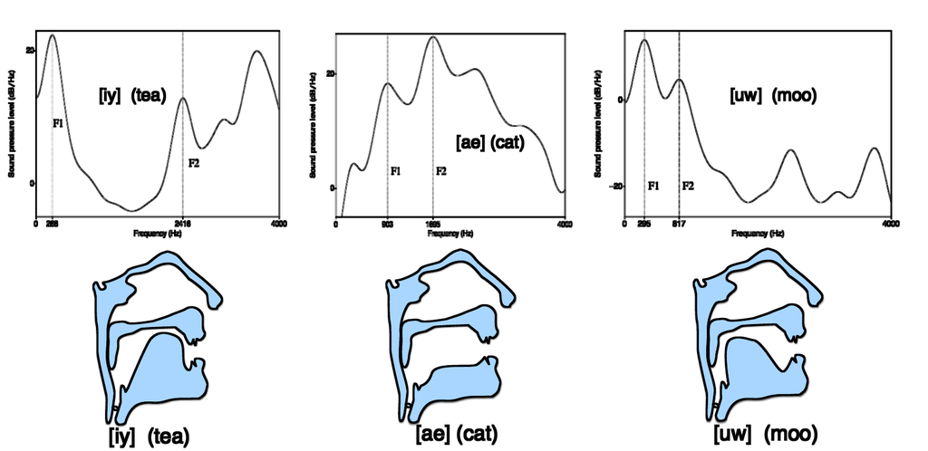

Reproduced from Jurafsky & Martin, *SLP* 3rd ed. (Aug 2026 draft), Fig. 15.24: tongue positions for three English vowels and the resulting smoothed spectra, F1 and F2 marked.

Same buzz in every case; only the filter changed. F1 falls as the tongue rises, F2 rises as it fronts: **the tract shape is legible in the spectrum**.

æ

The chart, rediscovered by measurement

## Peterson & Barney, 1952: the quadrilateral is data

Measure F1 and F2 for hundreds of speakers, plot with both axes flipped, and the IPA vowel chart **draws itself**.

The ellipses matter: every vowel is a **cloud**, not a point. Speaker variability is the whole story of Weeks 5–9.

One thing to notice: this is 1952 American English. Where would **Singapore English** vowels sit? Your own hVd recordings answer that within the hour, and if they land off these clouds, that is data, not error.

The phonetician's superpower

## Reading spectrograms like a linguist

### Stops

Silence (closure) → vertical spike (burst) → rapid formant transitions into the vowel. Place of articulation hides in the transition direction.

### Fricatives

High noise = /s/; lower, broader noise = /ʃ/; faint diffuse noise = /f θ/. Energy distribution is the cue.

### Vowels & glides

Formant positions = vowel quality; formant *movement* = diphthongs, glides, coarticulation with neighbors.

**Next week's punchline, planted now:** the “features” a recognizer extracts (MFCCs) are an automated, compressed version of exactly this skill: a machine doing narrow phonetic transcription of the acoustics, 100 times per second.

Housekeeping that is secretly a preview

## First recording week: your voice, your call

- Recording is **always optional**; every activity has provided fallback audio
- Your hVd set joins the class's pooled data **only if you opt in**
- Pooled recordings live in a **class-only folder**, deleted at term end
- Nothing leaves the course without **your explicit consent**

Voice is quasi-biometric data, and this policy is your first case study: in Week 9 we audit how the industry samples voices, and in Week 12 we clone one, with consent, on camera.

Break · 10 minutes · back at 11:50

Praat open. Colab tab open.  
Mic check: New → Record mono Sound.

No mic, or opting out? The fallback recordings are in the course repo; everything works the same.

The practical · 11:50–12:50

## Record it, break it, rebuild it

Praat block: one visit, then one upload

- Record the hVd set (“heed, hid, head, had, hod, hawed, hood, who'd”) + “She sees Sue's sheep” (no mic? fallback recordings provided)
- Narrowband vs wideband views of one vowel; measure F1/F2 at each vowel's midpoint

Colab block

- **Downsampling safari**: 16k → 8k → 4k → 2k Hz. Which segments die first? Check your ranking from the poll
- **Build a voice from sinusoids**: Fourier in reverse, one harmonic per cell
- **Hear aliasing**: synthesize the 3 kHz impostor; sweep a tone into the ceiling and listen to it bounce

**Take-home:** the formant round-trip (your vowels onto Week 1's chart, next to Peterson & Barney; SgE differences are findings, not errors) + annotated NB/WB screenshots. **Stretch:** KlattGrid: fix a 100 Hz source, morph the formants /ɑ/→/i/, and hear the filter alone change the vowel (Week 10 seed).

You leave with this, made by you

[figure not shown]

The practical · Praat cheat sheet

## Numbers to type, so nothing feels haunted

**Record:** New → Record mono Sound, 44100 Hz (resampling is the notebook's job)

**Narrowband:** Spectrogram settings → window length 0.025 s

**Wideband:** window length 0.005 s

**Formant ceiling:** 5000 Hz (typical male) · 5500 Hz (typical female)

**Measure:** click the vowel midpoint → Formant → Get first & second formant

If the formants look crazy

Check the ceiling first (wrong ceiling is the classic cause); avoid creaky stretches (move the cursor); and if your recording misbehaves, the fallback set in the repo is measured the same way. Write every F1/F2 pair down; the take-home needs them.

The practical · the hour, mapped

## By the end of the hour, you will have built this

**1.** Praat: record the hVd set (8 words), measure F1/F2 (20 min)

**2.** One upload to Colab (5 min)

**3.** Downsampling safari: 16k → 8k → 4k → 2k (15 min)

**4.** Build a voice from sinusoids (15 min)

**5.** Hear aliasing: synthesize the impostor (5 min)

DONE LOOKS LIKE

✓ eight F1/F2 pairs written down  
✓ you heard your own /s/ die at 4 kHz  
✓ a buzz you built from pure tones

The formant round-trip and NB/WB screenshots are take-home. Your recordings return next week as feature-extraction fodder.

In the textbook's words

## This week, formally

DEFINITION

Sampling rate & Nyquist frequency

“The sampling rate is the number of samples taken per second… to accurately measure a wave we must have at least two samples in each cycle.” The highest representable frequency, half the sampling rate, is the *Nyquist frequency*.

Jurafsky & Martin, *SLP* 3rd ed., ch. 15 (quoted; Aug 2026 draft).

DEFINITION

Spectrum

“The spectrum of a signal is a representation of each of its frequency components and their amplitudes.” A spectrogram is the spectrum unrolled over time.

Jurafsky & Martin, *SLP* 3rd ed., ch. 15 (quoted; Aug 2026 draft).

DEFINITION

Formant

“A formant is a frequency band that is particularly amplified by the vocal tract.” Different vowels = different tract shapes = different formant frequencies (F1, F2, …).

Jurafsky & Martin, *SLP* 3rd ed., ch. 15 (quoted; Aug 2026 draft).

DEFINITION

Source–filter model

Explains any speech sound as a *source* shaped by a *filter* (the vocal tract’s resonances). The source varies: the glottal buzz for vowels and voiced sounds, noise at a constriction for fricatives, a burst for stops.

Fant (1960); Jurafsky & Martin, *SLP* 3rd ed., ch. 15 (Aug 2026 draft).

Exercises · pencils out · ~6 minutes, in pairs

## Try it: counting cycles

EX 3.3

(a) What is the highest frequency a 16 kHz recording can faithfully represent? (b) A fricative has strong energy at 7 kHz. Will a telephone recording (8 kHz sampling) capture it, and what does your answer predict for the /s/–/f/ contrast on the phone?

EX 3.4

A voiced waveform repeats every 8 ms. (a) What is its F0? (b) Give the frequencies of its first three harmonics.

EX 3.5

A pure 7 kHz tone is sampled at 10 kHz with no anti-aliasing filter (Nyquist = 5 kHz). What apparent frequency will the impostor have?

EX 3.6

A 16-bit recording uses 2¹⁶ rungs. (a) Roughly what dynamic range, in dB, does that give? (b) A voice in a quiet room spans about 50 dB, so why do studios still record at 24-bit?

Worked answers in the appendix at the end of this deck.

Before next week

## This week’s readings

REQ**Hugging Face Audio Course, Unit 1: “Working with audio data”**

Waveforms, sampling rate, bit depth, spectrograms, with the exact librosa calls from the practical. Skim the code on first read. huggingface.co/learn/audio-course/chapter1/introduction

REQ**Schaedler, *Seeing Circles, Sines, and Signals* (interactive)**

Work through the sine-wave, sampling, and aliasing pages before the practical: the animations do in 30 seconds what a page of equations cannot. jackschaedler.github.io/circles-sines-signals

REQ**Jurafsky & Martin, *SLP* (3rd ed., free online): Ch 15, the phonetics & acoustics sections**

Waveforms, sampling, spectra, source–filter. Stop when it turns to feature extraction; that is next week's reading. web.stanford.edu/~jurafsky/slp3/15.pdf (chapter numbers follow the Aug 2026 draft)

OPT**3Blue1Brown, “But what is the Fourier Transform?” (video)**

The winding-machine visualization, for anyone who wants to open the black box. First 10 minutes are the payoff. 3blue1brown.com/lessons/fourier-transforms

OPT**Styler, *Using Praat for Linguistic Research***

Reference for the practical: the sections on spectrogram settings and formant measurement. wstyler.ucsd.edu/praat

Looking one week ahead

## Next week’s readings

REQ**Hugging Face Audio Course, Unit 1 · the “Introduction to audio data” section**

The exact librosa calls next week’s practical uses. huggingface.co/learn/audio-course/chapter1/audio_data

REQ**Fayek (2016), “Speech Processing for Machine Learning: Filter banks, MFCCs and What’s In-Between”**

The classic walkthrough of next week’s whole pipeline; focus on the figures. haythamfayek.com

REQ**Jurafsky & Martin, *SLP* §15.5 “Feature Extraction: Log Mel Spectrum” + §16.1 “The ASR Task”**

The textbook version of the same pipeline, then the first page of the recognition story. (Chapter numbers follow the Aug 2026 draft.)

OPT**Lyons, “Mel Frequency Cepstral Coefficients tutorial”**

A gentler second pass at the same material, with worked numbers. practicalcryptography.com (archived copy linked from NTULearn if the site is down)

**Next week:** the spectrogram is compressed into thirteen numbers per frame: the features every recognizer actually hears.

Wrap-up · quiz radar

## Five things to walk out with

- Compute a Nyquist limit and predict which sounds a sample rate kills
- Compute an alias (and say when the simple subtraction rule applies)
- Read F0 and its harmonics off a period (8 ms → 125, 250, 375 Hz)
- Choose narrowband vs wideband for a given question, and say why
- Tell the source's fingerprints from the filter's on a spectrogram

ɑ

The buzz proposes.  
The tract disposes.

Source × filter: that's a vowel, and that's half of speech technology. **Next week, “Thirteen Honest Numbers”:** we compress the spectrogram into the 13 numbers every recognizer actually hears.

Appendix · for the curious

## The product rule, derived

cos(a−b) = cos a cos b + sin a sin b

cos(a+b) = cos a cos b − sin a sin b

Two standard angle formulas. Their first terms are identical, so subtracting the second line from the first removes them:

cos(a−b) − cos(a+b) = 2 sin a sin b ⇒ sin a sin b = ½ cos(a−b) − ½ cos(a+b)

For two tones, a = 2πf₁t and b = 2πf₂t, so a−b grows at the **difference frequency** and a+b at the **sum frequency**: the two wobbles of the cancellation slide. The other products decompose the same way: cos · cos gives ½ cos(a−b) + ½ cos(a+b), and sin · cos gives sines of the same two angles.

The same fact powers more than analysis: making the sum and difference frequencies on purpose is how radio mixers and audible “beats” between two close tones work.

Sources

## References

**Jurafsky, D. & Martin, J. H.** *Speech and Language Processing*, 3rd ed. (Aug 2026 draft), Ch 15. The acoustics sections; the WAV header figure redrawn after Fig. 15.12; PCM and μ-law from §15.4.2, eq. (15.5); definitions quoted on the formal slide.

**Peterson, G. E. & Barney, H. L.** (1952). “Control methods used in a study of the vowels.” *JASA* 24(2), 175–184. The F1×F2 vowel data, as in Week 1.

**Fant, G.** (1960). *Acoustic Theory of Speech Production.* Mouton. The source–filter model.

**Shannon, C. E.** (1949). “Communication in the presence of noise.” *Proc. IRE* 37(1), 10–21. The sampling theorem as taught here; the limit is named for Nyquist (1928).

**Interactive resources:** Schaedler, *Seeing Circles, Sines, and Signals*; 3Blue1Brown, “But what is the Fourier Transform?”; Hugging Face Audio Course, Unit 1.

Appendix · worked answers

## Answers

EX 3.1

Amplitude A = **0.4**; frequency f = **250 Hz**; period T = 1⁄250 s = **4 ms**.

EX 3.2

y(t) = **2 · sin(2π · 100 · t + π⁄2)**: a quarter-turn = π⁄2. It sounds identical (same loudness, same pitch); only the starting point changed. Phase moved, the ear shrugged.

EX 3.3

(a) Half the sampling rate = **8 kHz**. (b) Telephone Nyquist = 4 kHz, so the 7 kHz energy is **lost**. /s/ keeps much of its energy above 4 kHz while /f/ is flatter; the phone strips exactly the cue that separates them.

EX 3.4

(a) F0 = 1 ⁄ 0.008 s = **125 Hz**. (b) Harmonics at integer multiples: **125, 250, 375 Hz**.

EX 3.5

Aliased frequency = |7 kHz − 10 kHz| = **3 kHz**: the impostor from the lecture figure. The 7 kHz tone masquerades as 3 kHz because the samples fit both. (One caution: this simple subtraction works only between Nyquist and the sample rate; the general rule is that frequencies **mirror around Nyquist**, folding back and forth, so a 17 kHz tone at 10 kHz sampling lands at 3 kHz too, not 7.)

EX 3.6

(a) About **6 × 16 = 96 dB** (2¹⁶ = 65,536 rungs). (b) The extra 8 bits are not for the listener: they are **headroom**, so you can record quietly and normalize later, and so the many processing steps that each round a little never reach the noise floor. On the finished voice, 16-bit already sits below the microphone's own hiss, so the steps stay inaudible.